# HNB DigiMedia Map 9: Event Attribution Analysis

Who Captures Attention When It Matters Most?

Author

HNB DigiMedia Project

Published

January 28, 2026

# 1 Introduction

This document presents **Map 9: Event Attribution Analysis** of the HNB DigiMedia project. The core question driving this analysis is:

> **Which actors capture attention during key policy events, and does HNB lose voice share when it matters most?**

## 1.1 Theoretical Motivation

The literature establishes that event windows are when central bank communication matters most:

1. **Market impact:** Born, Ehrmann, and Fratzscher (2012) documented that Financial Stability Reports move equity markets by more than 1% on average during the subsequent month
2. **Expectation formation:** Gürkaynak, Sack, and Swanson (2005) showed FOMC statements have greater impact on long-term yields than rate changes themselves
3. **Communication primacy:** Lucca and Trebbi (2009) found communication changes lead policy rate decisions by more than a year

For HNB, the critical question is whether official voice is maintained or displaced during high-salience events such as:

- ECB interest rate decisions
- Euro transition milestones
- Inflation announcements
- Major policy communications

## 1.2 Event Attribution Framework

We operationalize **voice share** as the proportion of total attention (REACH) captured by each actor type during defined event windows:

$$\text{Voice Share}_i = \frac{\text{REACH}_i}{\sum_j \text{REACH}_j} \times 100$$

**Event hijacking** occurs when non-institutional sources capture disproportionate attention during events that should feature institutional voice.

| Metric | Definition | Interpretation |
| --- | --- | --- |
| Voice Share | Actor REACH / Total REACH in window | Who dominates attention |
| Voice Delta | Event Voice Share - Baseline Voice Share | Change during events |
| Hijack Index | Media Voice Share / Institutional Voice Share | >1 = media dominates |
| Response Rank | Publication order after event | Who responds first |

```r
hnb <- readRDS("C:/Users/lsikic/Dropbox/hnb.rds")
setDT(hnb)

hnb[, date := as.Date(DATE)]
hnb[, year := year(date)]
hnb[, month := month(date)]

hnb[, period := fcase(
  date < as.Date("2023-01-01"), "ERM II",
  default = "Euro Era"
)]
hnb[, period := factor(period, levels = c("ERM II", "Euro Era"))]

n_articles <- nrow(hnb)
total_reach <- sum(hnb$REACH, na.rm = TRUE)

cat("Data loaded:", n_articles, "articles\n")
```

```
Data loaded: 19128 articles
```

```r
cat("Total REACH:", format(total_reach, big.mark = ","), "\n")
```

```
Total REACH: 52,352,866
```

```r
# =============================================================================
# ACTOR CLASSIFICATION - SYNCHRONIZED WITH MAPS 1-8
# =============================================================================

manual_overrides <- list(
  "HNB Official" = c(
    "hnb.hr", "hrvatska narodna banka",
    "hrvatska narodna banka / croatian national bank"
  ),
  "Financial Regulators" = c(
    "hanfa.hr", "hanfa", "hrvatska agencija za nadzor financijskih usluga",
    "fina.hr", "fina", "financijska agencija"
  ),
  "Government" = c(
    "gov.hr", "vlada", "vlada republike hrvatske",
    "ministarstvo financija", "sabor.hr"
  ),
  "Financial Media" = c(
    "poslovni.hr", "poslovni dnevnik", "seebiz.eu", "seebiz",
    "lider.media", "lidermedia.hr", "lider", "bloombergadria.com",
    "bloomberg adria", "hrportfolio.hr", "privredni.hr"
  ),
  "Commercial Banks" = c(
    "zaba.hr", "zagrebačka banka", "pbz.hr", "privredna banka zagreb",
    "erste.hr", "erste banka", "hpb.hr", "hrvatska poštanska banka",
    "otp banka", "raiffeisen", "addiko"
  ),
  "Academic/Expert" = c(
    "eizg.hr", "ekonomski institut zagreb", "ijf.hr",
    "institut za javne financije", "ekonomski fakultet"
  )
)

general_media_sources <- c(
  "index.hr", "index", "jutarnji.hr", "jutarnji", "jutarnji list",
  "vecernji.hr", "vecernji", "večernji list",
  "24sata.hr", "24sata", "slobodnadalmacija.hr", "slobodna dalmacija",
  "novilist.hr", "novi list", "dnevnik.hr", "dnevnik",
  "tportal.hr", "tportal", "telegram.hr", "telegram",
  "net.hr", "rtl.hr", "rtl", "hrt.hr", "hrt",
  "n1info.hr", "n1info.com", "n1", "nacional.hr", "nacional",
  "direktno.hr", "direktno", "dnevno.hr", "dnevno"
)

classify_actor_hnb <- function(from_val, url_val = NA) {
  from_lower <- tolower(trimws(as.character(from_val)))
  url_lower <- tolower(ifelse(is.na(url_val), "", as.character(url_val)))
  combined <- paste(from_lower, url_lower)

  match_any <- function(patterns, text, fixed = TRUE) {
    any(sapply(patterns, function(p) grepl(p, text, fixed = fixed)))
  }

  for (actor_type in names(manual_overrides)) {
    if (match_any(manual_overrides[[actor_type]], from_lower)) {
      return(actor_type)
    }
  }

  if (grepl("hnb\\.hr", url_lower) || grepl("hnb\\.hr", from_lower)) {
    return("HNB Official")
  }

  if (grepl("hanfa|fina\\.hr", combined)) {
    return("Financial Regulators")
  }

  if (grepl("gov\\.hr|vlada|ministarstvo", combined)) {
    return("Government")
  }

  bank_patterns <- c("banka", "bank", "zaba", "pbz", "erste", "hpb",
                     "otp", "raiffeisen", "addiko", "sberbank")
  if (match_any(bank_patterns, from_lower)) {
    if (!grepl("narodna|hnb|central", from_lower)) {
      return("Commercial Banks")
    }
  }

  financial_media_patterns <- c(
    "poslovni", "seebiz", "lider", "bloomberg", "portfolio",
    "privredni", "finance", "ekonom", "business", "capital"
  )
  if (match_any(financial_media_patterns, from_lower)) {
    return("Financial Media")
  }

  if (match_any(general_media_sources, from_lower)) {
    return("General Media")
  }

  news_patterns <- c("portal", "vijesti", "news", "info", "dnevni",
                     "radio", "tv", ".hr")
  if (match_any(news_patterns, from_lower)) {
    return("General Media")
  }

  return("Other")
}

hnb[, ACTOR_TYPE := mapply(classify_actor_hnb, FROM, URL)]
hnb[, INSTITUTIONAL := ACTOR_TYPE %in% c("HNB Official", "Financial Regulators", "Government")]
```

# 2 Analysis 9.1: Event Calendar Definition

## 2.1 Key Events in HNB Coverage Period

```r
# Define comprehensive event calendar
events <- data.table(
  Event = c(
    # Euro Transition Events
    "Euro Adoption Day",
    "Conversion Rate Announcement",
    "Euro Coins Presentation",
    "Dual Display Start",
    "ERM II Entry Anniversary",
    "Final HRK Day",

    # ECB Policy Events
    "ECB First Rate Hike 2022",
    "ECB Large Rate Hike Sept 2022",
    "ECB Rate Hike Oct 2022",
    "ECB Rate Hike Dec 2022",
    "ECB Rate Hike Feb 2023",
    "ECB Rate Hike March 2023",
    "ECB Rate Hike May 2023",
    "ECB Rate Hike June 2023",
    "ECB Rate Hike July 2023",
    "ECB Rate Hike Sept 2023",

    # Inflation Events
    "Croatia CPI Peak Oct 2022",
    "Eurozone Inflation Peak",
    "Croatia CPI Deceleration Start",

    # HNB Policy Events
    "HNB Final Rate Decision",
    "HNB Governor Statement Euro",
    "HNB Annual Report 2021",
    "HNB Annual Report 2022",

    # Banking Events
    "Credit Suisse Crisis",
    "SVB Collapse"
  ),
  Date = as.Date(c(
    # Euro Transition
    "2023-01-01",
    "2022-07-12",
    "2022-11-22",
    "2022-09-05",
    "2021-07-10",
    "2022-12-31",

    # ECB Policy
    "2022-07-21",
    "2022-09-08",
    "2022-10-27",
    "2022-12-15",
    "2023-02-02",
    "2023-03-16",
    "2023-05-04",
    "2023-06-15",
    "2023-07-27",
    "2023-09-14",

    # Inflation
    "2022-10-15",
    "2022-10-31",
    "2023-03-01",

    # HNB Policy
    "2022-12-15",
    "2022-06-01",
    "2022-05-15",
    "2023-05-15",

    # Banking
    "2023-03-15",
    "2023-03-10"
  )),
  Type = c(
    rep("Euro Transition", 6),
    rep("ECB Policy", 10),
    rep("Inflation", 3),
    rep("HNB Policy", 4),
    rep("Banking", 2)
  ),
  Window_Days = c(
    rep(7, 6),   # Euro events: 7 day window
    rep(3, 10),  # ECB: 3 day window
    rep(5, 3),   # Inflation: 5 day window
    rep(5, 4),   # HNB: 5 day window
    rep(5, 2)    # Banking: 5 day window
  ),
  Expected_Leader = c(
    rep("HNB Official", 6),
    rep("Financial Media", 10),
    rep("Financial Media", 3),
    rep("HNB Official", 4),
    rep("Financial Media", 2)
  )
)

# Filter to events within data range
data_min <- min(hnb$date)
data_max <- max(hnb$date)
events <- events[Date >= data_min & Date <= data_max]

cat("Event Calendar\n")
```

```
Event Calendar
```

```r
cat("==============\n")
cat("Total events defined:", nrow(events), "\n")
```

```
Total events defined: 25
```

```r
cat("Event types:", paste(unique(events$Type), collapse = ", "), "\n")
```

```
Event types: Euro Transition, ECB Policy, Inflation, HNB Policy, Banking
```

```r
cat("Date range:", as.character(data_min), "to", as.character(data_max), "\n")
```

```
Date range: 2021-01-01 to 2023-12-31
```

```r
events %>%
  arrange(Date) %>%
  mutate(
    Date = as.character(Date),
    Window = paste0("±", Window_Days, " days")
  ) %>%
  select(Event, Date, Type, Window, Expected_Leader) %>%
  kable(col.names = c("Event", "Date", "Type", "Window", "Expected Voice Leader")) %>%
  kable_styling(bootstrap_options = c("striped", "hover"), full_width = FALSE) %>%
  scroll_box(height = "400px")
```

| Event | Date | Type | Window | Expected Voice Leader |
| --- | --- | --- | --- | --- |
| ERM II Entry Anniversary | 2021-07-10 | Euro Transition | ±7 days | HNB Official |
| HNB Annual Report 2021 | 2022-05-15 | HNB Policy | ±5 days | HNB Official |
| HNB Governor Statement Euro | 2022-06-01 | HNB Policy | ±5 days | HNB Official |
| Conversion Rate Announcement | 2022-07-12 | Euro Transition | ±7 days | HNB Official |
| ECB First Rate Hike 2022 | 2022-07-21 | ECB Policy | ±3 days | Financial Media |
| Dual Display Start | 2022-09-05 | Euro Transition | ±7 days | HNB Official |
| ECB Large Rate Hike Sept 2022 | 2022-09-08 | ECB Policy | ±3 days | Financial Media |
| Croatia CPI Peak Oct 2022 | 2022-10-15 | Inflation | ±5 days | Financial Media |
| ECB Rate Hike Oct 2022 | 2022-10-27 | ECB Policy | ±3 days | Financial Media |
| Eurozone Inflation Peak | 2022-10-31 | Inflation | ±5 days | Financial Media |
| Euro Coins Presentation | 2022-11-22 | Euro Transition | ±7 days | HNB Official |
| ECB Rate Hike Dec 2022 | 2022-12-15 | ECB Policy | ±3 days | Financial Media |
| HNB Final Rate Decision | 2022-12-15 | HNB Policy | ±5 days | HNB Official |
| Final HRK Day | 2022-12-31 | Euro Transition | ±7 days | HNB Official |
| Euro Adoption Day | 2023-01-01 | Euro Transition | ±7 days | HNB Official |
| ECB Rate Hike Feb 2023 | 2023-02-02 | ECB Policy | ±3 days | Financial Media |
| Croatia CPI Deceleration Start | 2023-03-01 | Inflation | ±5 days | Financial Media |
| SVB Collapse | 2023-03-10 | Banking | ±5 days | Financial Media |
| Credit Suisse Crisis | 2023-03-15 | Banking | ±5 days | Financial Media |
| ECB Rate Hike March 2023 | 2023-03-16 | ECB Policy | ±3 days | Financial Media |
| ECB Rate Hike May 2023 | 2023-05-04 | ECB Policy | ±3 days | Financial Media |
| HNB Annual Report 2022 | 2023-05-15 | HNB Policy | ±5 days | HNB Official |
| ECB Rate Hike June 2023 | 2023-06-15 | ECB Policy | ±3 days | Financial Media |
| ECB Rate Hike July 2023 | 2023-07-27 | ECB Policy | ±3 days | Financial Media |
| ECB Rate Hike Sept 2023 | 2023-09-14 | ECB Policy | ±3 days | Financial Media |

# 3 Analysis 9.2: Baseline Voice Share

## 3.1 Overall Voice Share (Non-Event Periods)

```r
# Calculate baseline (all data)
baseline_voice <- hnb[, .(
  Articles = .N,
  Total_REACH = sum(REACH, na.rm = TRUE),
  Mean_REACH = mean(REACH, na.rm = TRUE)
), by = ACTOR_TYPE]

baseline_voice[, `:=`(
  Article_Share = Articles / sum(Articles) * 100,
  REACH_Share = Total_REACH / sum(Total_REACH) * 100
)]

baseline_voice <- baseline_voice[order(-REACH_Share)]

# Store for later comparison
baseline_hnb_voice <- baseline_voice[ACTOR_TYPE == "HNB Official", REACH_Share]
baseline_institutional_voice <- baseline_voice[ACTOR_TYPE %in% c("HNB Official", "Financial Regulators", "Government"), sum(REACH_Share)]
baseline_media_voice <- baseline_voice[ACTOR_TYPE %in% c("Financial Media", "General Media"), sum(REACH_Share)]
```

## 3.2 Baseline Voice Share Visualization

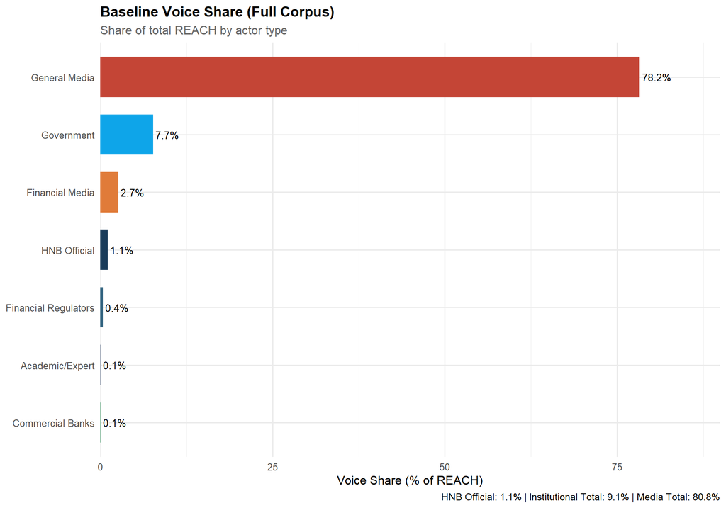

```r
ggplot(baseline_voice[ACTOR_TYPE != "Other"],
       aes(x = reorder(ACTOR_TYPE, REACH_Share), y = REACH_Share, fill = ACTOR_TYPE)) +
  geom_col(width = 0.7) +
  geom_text(aes(label = sprintf("%.1f%%", REACH_Share)), hjust = -0.1, size = 3.5) +
  coord_flip() +
  scale_fill_manual(values = actor_colors) +
  scale_y_continuous(expand = expansion(mult = c(0, 0.15))) +
  labs(
    title = "Baseline Voice Share (Full Corpus)",
    subtitle = "Share of total REACH by actor type",
    x = NULL,
    y = "Voice Share (% of REACH)",
    caption = paste0("HNB Official: ", sprintf("%.1f%%", baseline_hnb_voice),
                    " | Institutional Total: ", sprintf("%.1f%%", baseline_institutional_voice),
                    " | Media Total: ", sprintf("%.1f%%", baseline_media_voice))
  ) +
  theme(legend.position = "none")
```

# 4 Analysis 9.3: Event-Specific Voice Share

## 4.1 Calculate Voice Share for Each Event

```r
# Function to calculate voice share for an event window
calculate_event_voice <- function(event_date, window_days) {
  window_start <- event_date - window_days
  window_end <- event_date + window_days

  event_data <- hnb[date >= window_start & date <= window_end]

  if (nrow(event_data) == 0) return(NULL)

  voice <- event_data[, .(
    Articles = .N,
    Total_REACH = sum(REACH, na.rm = TRUE)
  ), by = ACTOR_TYPE]

  voice[, `:=`(
    Article_Share = Articles / sum(Articles) * 100,
    REACH_Share = Total_REACH / sum(Total_REACH) * 100
  )]

  return(voice)
}

# Calculate voice share for all events
event_voice_list <- list()

for (i in 1:nrow(events)) {
  voice <- calculate_event_voice(events$Date[i], events$Window_Days[i])
  if (!is.null(voice)) {
    voice[, Event := events$Event[i]]
    voice[, Event_Type := events$Type[i]]
    voice[, Event_Date := events$Date[i]]
    event_voice_list[[i]] <- voice
  }
}

event_voice <- rbindlist(event_voice_list)

# Calculate HNB voice share for each event
hnb_event_voice <- event_voice[ACTOR_TYPE == "HNB Official", .(
  Event, Event_Type, Event_Date,
  HNB_Articles = Articles,
  HNB_REACH = Total_REACH,
  HNB_Voice_Share = REACH_Share
)]

# Add baseline comparison
hnb_event_voice[, Baseline_Voice := baseline_hnb_voice]
hnb_event_voice[, Voice_Delta := HNB_Voice_Share - Baseline_Voice]
```

## 4.2 HNB Voice Share Across Events

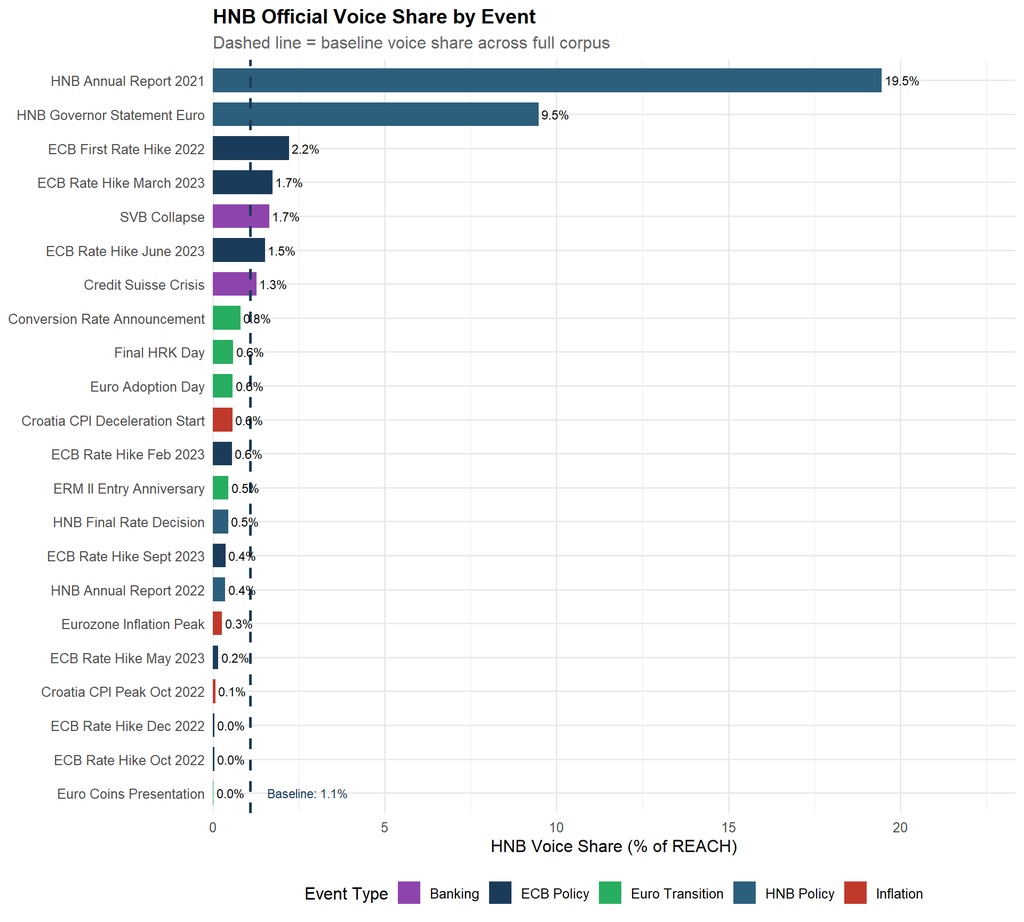

```r
ggplot(hnb_event_voice, aes(x = reorder(Event, HNB_Voice_Share), y = HNB_Voice_Share, fill = Event_Type)) +
  geom_col(width = 0.7) +
  geom_hline(yintercept = baseline_hnb_voice, linetype = "dashed", color = "#1a3c5a", linewidth = 1) +
  geom_text(aes(label = sprintf("%.1f%%", HNB_Voice_Share)), hjust = -0.1, size = 3) +
  coord_flip() +
  scale_fill_manual(values = event_type_colors) +
  scale_y_continuous(expand = expansion(mult = c(0, 0.2))) +
  annotate("text", x = 1, y = baseline_hnb_voice + 0.5,
           label = paste0("Baseline: ", sprintf("%.1f%%", baseline_hnb_voice)),
           hjust = 0, size = 3, color = "#1a3c5a") +
  labs(
    title = "HNB Official Voice Share by Event",
    subtitle = "Dashed line = baseline voice share across full corpus",
    x = NULL,
    y = "HNB Voice Share (% of REACH)",
    fill = "Event Type"
  )
```

## 4.3 Voice Delta Analysis

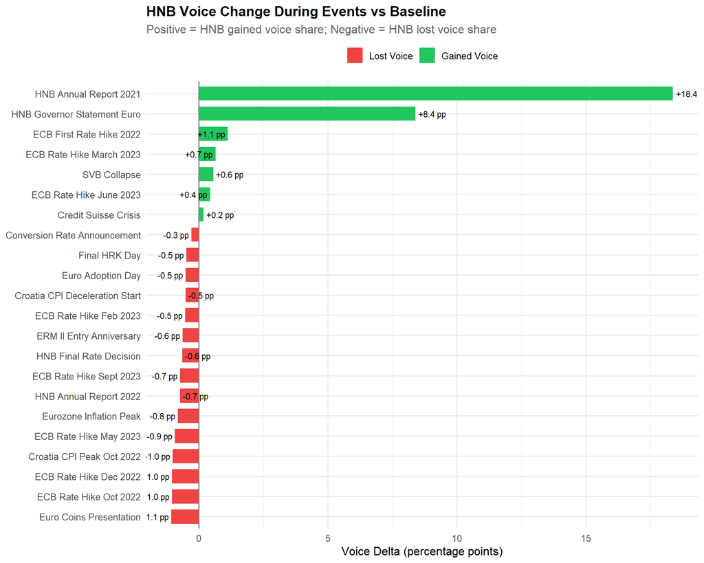

```r
ggplot(hnb_event_voice, aes(x = reorder(Event, Voice_Delta), y = Voice_Delta, fill = Voice_Delta > 0)) +
  geom_col(width = 0.7) +
  geom_hline(yintercept = 0, color = "gray50") +
  geom_text(aes(label = sprintf("%+.1f pp", Voice_Delta)),
            hjust = ifelse(hnb_event_voice[order(Voice_Delta)]$Voice_Delta > 0, -0.1, 1.1),
            size = 3) +
  coord_flip() +
  scale_fill_manual(values = c("TRUE" = "#22c55e", "FALSE" = "#ef4444"),
                    labels = c("TRUE" = "Gained Voice", "FALSE" = "Lost Voice")) +
  labs(
    title = "HNB Voice Change During Events vs Baseline",
    subtitle = "Positive = HNB gained voice share; Negative = HNB lost voice share",
    x = NULL,
    y = "Voice Delta (percentage points)",
    fill = NULL
  ) +
  theme(legend.position = "top")
```

## 4.4 Event Voice Summary Table

```r
hnb_event_voice[order(Event_Date)] %>%
  mutate(
    Event_Date = as.character(Event_Date),
    HNB_Articles = format(HNB_Articles, big.mark = ","),
    HNB_REACH = format(HNB_REACH, big.mark = ","),
    HNB_Voice_Share = sprintf("%.2f%%", HNB_Voice_Share),
    Baseline_Voice = sprintf("%.2f%%", Baseline_Voice),
    Voice_Delta = sprintf("%+.2f pp", Voice_Delta),
    Performance = ifelse(as.numeric(gsub("[^0-9.-]", "", Voice_Delta)) > 0, "Above", "Below")
  ) %>%
  select(Event, Event_Type, Event_Date, HNB_Voice_Share, Voice_Delta, Performance) %>%
  kable(col.names = c("Event", "Type", "Date", "HNB Voice", "Delta", "vs Baseline")) %>%
  kable_styling(bootstrap_options = c("striped", "hover"), full_width = FALSE) %>%
  scroll_box(height = "400px")
```

| Event | Type | Date | HNB Voice | Delta | vs Baseline |
| --- | --- | --- | --- | --- | --- |
| ERM II Entry Anniversary | Euro Transition | 2021-07-10 | 0.46% | -0.62 pp | Below |
| HNB Annual Report 2021 | HNB Policy | 2022-05-15 | 19.46% | +18.37 pp | Above |
| HNB Governor Statement Euro | HNB Policy | 2022-06-01 | 9.49% | +8.40 pp | Above |
| Conversion Rate Announcement | Euro Transition | 2022-07-12 | 0.81% | -0.27 pp | Below |
| ECB First Rate Hike 2022 | ECB Policy | 2022-07-21 | 2.21% | +1.13 pp | Above |
| Croatia CPI Peak Oct 2022 | Inflation | 2022-10-15 | 0.08% | -1.00 pp | Below |
| ECB Rate Hike Oct 2022 | ECB Policy | 2022-10-27 | 0.04% | -1.04 pp | Below |
| Eurozone Inflation Peak | Inflation | 2022-10-31 | 0.27% | -0.81 pp | Below |
| Euro Coins Presentation | Euro Transition | 2022-11-22 | 0.02% | -1.06 pp | Below |
| ECB Rate Hike Dec 2022 | ECB Policy | 2022-12-15 | 0.05% | -1.04 pp | Below |
| HNB Final Rate Decision | HNB Policy | 2022-12-15 | 0.45% | -0.63 pp | Below |
| Final HRK Day | Euro Transition | 2022-12-31 | 0.60% | -0.49 pp | Below |
| Euro Adoption Day | Euro Transition | 2023-01-01 | 0.58% | -0.50 pp | Below |
| ECB Rate Hike Feb 2023 | ECB Policy | 2023-02-02 | 0.56% | -0.52 pp | Below |
| Croatia CPI Deceleration Start | Inflation | 2023-03-01 | 0.58% | -0.50 pp | Below |
| SVB Collapse | Banking | 2023-03-10 | 1.65% | +0.57 pp | Above |
| Credit Suisse Crisis | Banking | 2023-03-15 | 1.27% | +0.19 pp | Above |
| ECB Rate Hike March 2023 | ECB Policy | 2023-03-16 | 1.73% | +0.65 pp | Above |
| ECB Rate Hike May 2023 | ECB Policy | 2023-05-04 | 0.17% | -0.92 pp | Below |
| HNB Annual Report 2022 | HNB Policy | 2023-05-15 | 0.37% | -0.72 pp | Below |
| ECB Rate Hike June 2023 | ECB Policy | 2023-06-15 | 1.52% | +0.44 pp | Above |
| ECB Rate Hike Sept 2023 | ECB Policy | 2023-09-14 | 0.37% | -0.71 pp | Below |

# 5 Analysis 9.4: Event Hijacking Analysis

## 5.1 Who Captures Voice During Key Events?

```r
# Calculate institutional vs media voice for each event
inst_media_voice <- event_voice[, .(
  Institutional_REACH = sum(Total_REACH[ACTOR_TYPE %in% c("HNB Official", "Financial Regulators", "Government")]),
  Media_REACH = sum(Total_REACH[ACTOR_TYPE %in% c("Financial Media", "General Media")]),
  Total_REACH = sum(Total_REACH)
), by = .(Event, Event_Type, Event_Date)]

inst_media_voice[, `:=`(
  Institutional_Voice = Institutional_REACH / Total_REACH * 100,
  Media_Voice = Media_REACH / Total_REACH * 100
)]

inst_media_voice[, Hijack_Index := Media_Voice / Institutional_Voice]

# Add expected leader
inst_media_voice <- merge(inst_media_voice, events[, .(Event, Expected_Leader)], by = "Event")

# Determine if hijacked
inst_media_voice[, Hijacked := (Expected_Leader == "HNB Official" & Hijack_Index > 2) |
                               (Expected_Leader == "HNB Official" & Institutional_Voice < 10)]
```

## 5.2 Hijack Index Visualization

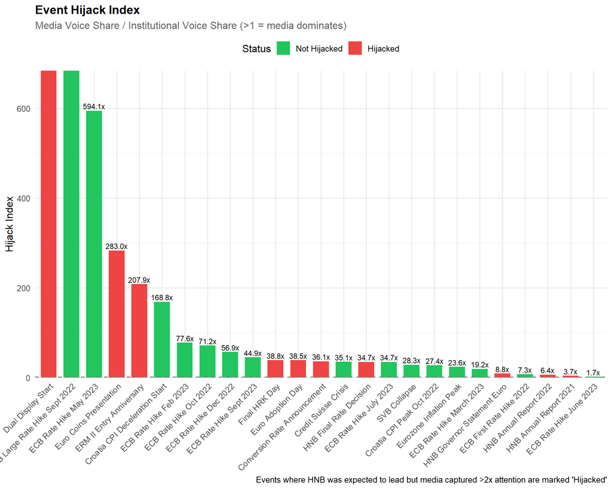

```r
ggplot(inst_media_voice, aes(x = reorder(Event, -Hijack_Index), y = Hijack_Index, fill = Hijacked)) +
  geom_col(width = 0.7) +
  geom_hline(yintercept = 1, linetype = "dashed", color = "gray50") +
  geom_text(aes(label = sprintf("%.1fx", Hijack_Index)), vjust = -0.3, size = 3) +
  scale_fill_manual(values = c("TRUE" = "#ef4444", "FALSE" = "#22c55e"),
                    labels = c("TRUE" = "Hijacked", "FALSE" = "Not Hijacked")) +
  scale_y_continuous(expand = expansion(mult = c(0, 0.15))) +
  labs(
    title = "Event Hijack Index",
    subtitle = "Media Voice Share / Institutional Voice Share (>1 = media dominates)",
    x = NULL,
    y = "Hijack Index",
    fill = "Status",
    caption = "Events where HNB was expected to lead but media captured >2x attention are marked 'Hijacked'"
  ) +
  theme(axis.text.x = element_text(angle = 45, hjust = 1), legend.position = "top")
```

## 5.3 Voice Composition by Event

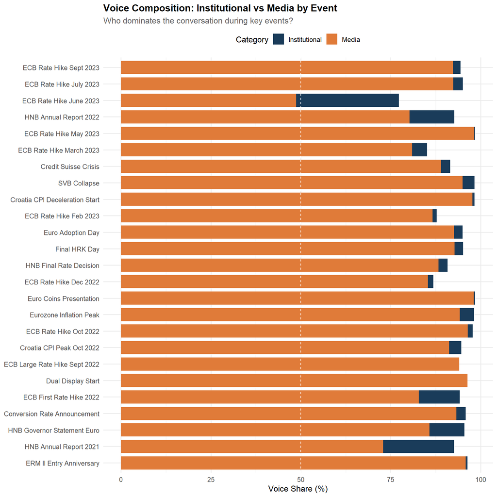

```r
# Prepare stacked bar data
voice_composition <- inst_media_voice %>%
  select(Event, Event_Type, Event_Date, Institutional_Voice, Media_Voice) %>%
  pivot_longer(cols = c(Institutional_Voice, Media_Voice),
               names_to = "Category", values_to = "Voice_Share") %>%
  mutate(Category = ifelse(Category == "Institutional_Voice", "Institutional", "Media"))

ggplot(voice_composition, aes(x = reorder(Event, Event_Date), y = Voice_Share, fill = Category)) +
  geom_col(width = 0.8) +
  geom_hline(yintercept = 50, linetype = "dashed", color = "white", linewidth = 0.5) +
  coord_flip() +
  scale_fill_manual(values = c("Institutional" = "#1a3c5a", "Media" = "#e07b39")) +
  labs(
    title = "Voice Composition: Institutional vs Media by Event",
    subtitle = "Who dominates the conversation during key events?",
    x = NULL,
    y = "Voice Share (%)",
    fill = "Category"
  ) +
  theme(legend.position = "top")
```

# 6 Analysis 9.5: Event Type Patterns

## 6.1 Voice Share by Event Type

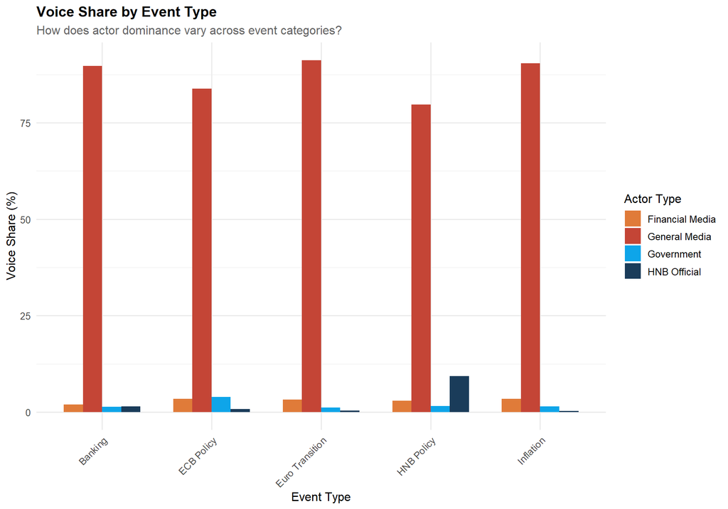

```r
event_type_voice <- event_voice[, .(
  Events = uniqueN(Event),
  Articles = sum(Articles),
  Total_REACH = sum(Total_REACH)
), by = .(Event_Type, ACTOR_TYPE)]

event_type_voice[, Voice_Share := Total_REACH / sum(Total_REACH) * 100, by = Event_Type]

# Focus on key actors
key_actors <- c("HNB Official", "Financial Media", "General Media", "Government")
event_type_key <- event_type_voice[ACTOR_TYPE %in% key_actors]

ggplot(event_type_key, aes(x = Event_Type, y = Voice_Share, fill = ACTOR_TYPE)) +
  geom_col(position = "dodge", width = 0.7) +
  scale_fill_manual(values = actor_colors) +
  labs(
    title = "Voice Share by Event Type",
    subtitle = "How does actor dominance vary across event categories?",
    x = "Event Type",
    y = "Voice Share (%)",
    fill = "Actor Type"
  ) +
  theme(axis.text.x = element_text(angle = 45, hjust = 1), legend.position = "right")
```

## 6.2 HNB Performance by Event Type

```r
hnb_by_type <- hnb_event_voice[, .(
  Events = .N,
  Mean_Voice_Share = mean(HNB_Voice_Share),
  Mean_Delta = mean(Voice_Delta),
  Events_Above_Baseline = sum(Voice_Delta > 0),
  Events_Below_Baseline = sum(Voice_Delta < 0)
), by = Event_Type]

hnb_by_type %>%
  mutate(
    Mean_Voice_Share = sprintf("%.2f%%", Mean_Voice_Share),
    Mean_Delta = sprintf("%+.2f pp", Mean_Delta),
    Success_Rate = sprintf("%.0f%%", Events_Above_Baseline / Events * 100)
  ) %>%
  select(Event_Type, Events, Mean_Voice_Share, Mean_Delta, Events_Above_Baseline, Events_Below_Baseline, Success_Rate) %>%
  kable(col.names = c("Event Type", "Events", "Mean Voice", "Mean Delta",
                      "Above Baseline", "Below Baseline", "Success Rate")) %>%
  kable_styling(bootstrap_options = c("striped", "hover"), full_width = FALSE)
```

| Event Type | Events | Mean Voice | Mean Delta | Above Baseline | Below Baseline | Success Rate |
| --- | --- | --- | --- | --- | --- | --- |
| Euro Transition | 5 | 0.50% | -0.59 pp | 0 | 5 | 0% |
| ECB Policy | 8 | 0.83% | -0.25 pp | 3 | 5 | 38% |
| Inflation | 3 | 0.31% | -0.77 pp | 0 | 3 | 0% |
| HNB Policy | 4 | 7.44% | +6.36 pp | 2 | 2 | 50% |
| Banking | 2 | 1.46% | +0.38 pp | 2 | 0 | 100% |

# 7 Analysis 9.6: High-Salience vs Normal Period Comparison

## 7.1 Define High-Salience Periods

```r
# Mark all dates within event windows as high-salience
hnb[, High_Salience := FALSE]

for (i in 1:nrow(events)) {
  event_date <- events$Date[i]
  window_days <- events$Window_Days[i]
  hnb[date >= (event_date - window_days) & date <= (event_date + window_days),
      High_Salience := TRUE]
}

hnb[, Salience := ifelse(High_Salience, "High Salience", "Normal")]

salience_summary <- hnb[, .(
  Days = uniqueN(date),
  Articles = .N,
  Total_REACH = sum(REACH, na.rm = TRUE)
), by = Salience]

salience_summary[, `:=`(
  Articles_Per_Day = Articles / Days,
  REACH_Per_Day = Total_REACH / Days
)]

salience_summary %>%
  mutate(
    Articles = format(Articles, big.mark = ","),
    Total_REACH = format(Total_REACH, big.mark = ","),
    Articles_Per_Day = sprintf("%.1f", Articles_Per_Day),
    REACH_Per_Day = format(round(REACH_Per_Day, 0), big.mark = ",")
  ) %>%
  kable(col.names = c("Period Type", "Days", "Articles", "Total REACH",
                      "Articles/Day", "REACH/Day")) %>%
  kable_styling(bootstrap_options = c("striped", "hover"), full_width = FALSE)
```

| Period Type | Days | Articles | Total REACH | Articles/Day | REACH/Day |
| --- | --- | --- | --- | --- | --- |
| Normal | 852 | 15,007 | 41,794,023 | 17.6 | 49,054 |
| High Salience | 198 | 4,121 | 10,558,843 | 20.8 | 53,327 |

## 7.2 Voice Share Comparison: High-Salience vs Normal

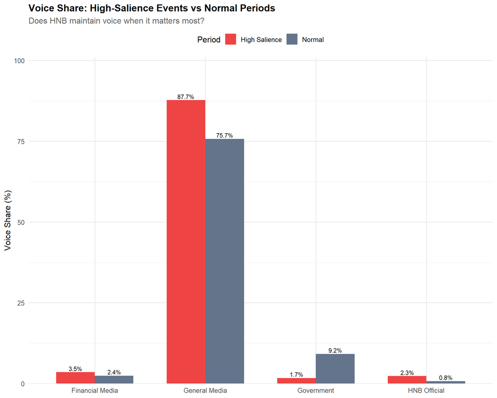

```r
salience_voice <- hnb[, .(
  Articles = .N,
  Total_REACH = sum(REACH, na.rm = TRUE)
), by = .(Salience, ACTOR_TYPE)]

salience_voice[, Voice_Share := Total_REACH / sum(Total_REACH) * 100, by = Salience]

# Compare key actors
salience_key <- salience_voice[ACTOR_TYPE %in% key_actors]

ggplot(salience_key, aes(x = ACTOR_TYPE, y = Voice_Share, fill = Salience)) +
  geom_col(position = "dodge", width = 0.7) +
  geom_text(aes(label = sprintf("%.1f%%", Voice_Share)),
            position = position_dodge(width = 0.7), vjust = -0.3, size = 3) +
  scale_fill_manual(values = salience_colors) +
  scale_y_continuous(expand = expansion(mult = c(0, 0.15))) +
  labs(
    title = "Voice Share: High-Salience Events vs Normal Periods",
    subtitle = "Does HNB maintain voice when it matters most?",
    x = NULL,
    y = "Voice Share (%)",
    fill = "Period"
  ) +
  theme(legend.position = "top")
```

## 7.3 Voice Delta by Salience

```r
# Calculate voice delta between high-salience and normal
salience_wide <- dcast(salience_voice, ACTOR_TYPE ~ Salience, value.var = "Voice_Share")
setnames(salience_wide, c("High Salience", "Normal"), c("High_Salience", "Normal"))
salience_wide[, Voice_Delta := High_Salience - Normal]

salience_wide[ACTOR_TYPE %in% key_actors][order(-Voice_Delta)] %>%
  mutate(
    High_Salience = sprintf("%.2f%%", High_Salience),
    Normal = sprintf("%.2f%%", Normal),
    Voice_Delta = sprintf("%+.2f pp", Voice_Delta),
    Effect = ifelse(as.numeric(gsub("[^0-9.-]", "", Voice_Delta)) > 0,
                    "Gains during events", "Loses during events")
  ) %>%
  kable(col.names = c("Actor Type", "High Salience", "Normal", "Delta", "Effect")) %>%
  kable_styling(bootstrap_options = c("striped", "hover"), full_width = FALSE)
```

| Actor Type | High Salience | Normal | Delta | Effect |
| --- | --- | --- | --- | --- |
| General Media | 87.74% | 75.74% | +12.00 pp | Gains during events |
| HNB Official | 2.34% | 0.77% | +1.58 pp | Gains during events |
| Financial Media | 3.51% | 2.44% | +1.06 pp | Gains during events |
| Government | 1.71% | 9.18% | -7.47 pp | Loses during events |

# 8 Analysis 9.7: Response Speed Analysis

## 8.1 Who Publishes First After Events?

```r
# For each event, find first responders on event day and day after
first_responders <- data.table()

for (i in 1:nrow(events)) {
  event_date <- events$Date[i]
  event_name <- events$Event[i]

  # Get articles on event day and day after
  response_window <- hnb[date >= event_date & date <= event_date + 1]

  if (nrow(response_window) > 0) {
    # Rank by date (and time if available)
    response_window[, Response_Rank := frank(date, ties.method = "min")]

    # Get first responder per actor type
    first_by_actor <- response_window[, .(
      First_Response_Date = min(date),
      Articles = .N,
      Total_REACH = sum(REACH, na.rm = TRUE)
    ), by = ACTOR_TYPE]

    first_by_actor[, `:=`(
      Event = event_name,
      Event_Date = event_date,
      Response_Lag = as.integer(First_Response_Date - event_date)
    )]

    first_responders <- rbind(first_responders, first_by_actor)
  }
}
```

## 8.2 Response Speed by Actor Type

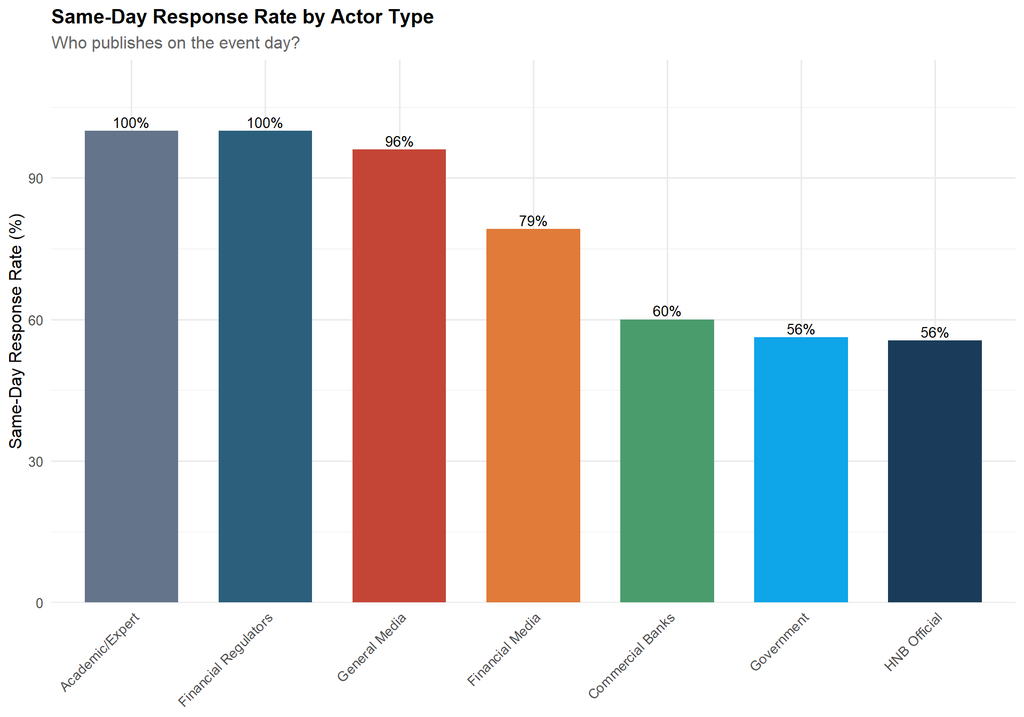

```r
if (nrow(first_responders) > 0) {
  response_summary <- first_responders[, .(
    Events_Responded = .N,
    Mean_Lag = mean(Response_Lag, na.rm = TRUE),
    Same_Day_Responses = sum(Response_Lag == 0),
    Total_First_Day_REACH = sum(Total_REACH[Response_Lag <= 1], na.rm = TRUE)
  ), by = ACTOR_TYPE][order(Mean_Lag)]

  response_summary[, Same_Day_Rate := Same_Day_Responses / Events_Responded * 100]

  ggplot(response_summary[ACTOR_TYPE != "Other"],
         aes(x = reorder(ACTOR_TYPE, -Same_Day_Rate), y = Same_Day_Rate, fill = ACTOR_TYPE)) +
    geom_col(width = 0.7) +
    geom_text(aes(label = sprintf("%.0f%%", Same_Day_Rate)), vjust = -0.3, size = 3.5) +
    scale_fill_manual(values = actor_colors) +
    scale_y_continuous(expand = expansion(mult = c(0, 0.15)), limits = c(0, 100)) +
    labs(
      title = "Same-Day Response Rate by Actor Type",
      subtitle = "Who publishes on the event day?",
      x = NULL,
      y = "Same-Day Response Rate (%)"
    ) +
    theme(legend.position = "none", axis.text.x = element_text(angle = 45, hjust = 1))
}
```

## 8.3 Response Speed Table

```r
if (nrow(first_responders) > 0) {
  response_summary %>%
    mutate(
      Events_Responded = format(Events_Responded, big.mark = ","),
      Mean_Lag = sprintf("%.1f days", Mean_Lag),
      Same_Day_Rate = sprintf("%.0f%%", Same_Day_Rate),
      Total_First_Day_REACH = format(Total_First_Day_REACH, big.mark = ",")
    ) %>%
    select(ACTOR_TYPE, Events_Responded, Mean_Lag, Same_Day_Rate, Total_First_Day_REACH) %>%
    kable(col.names = c("Actor Type", "Events Covered", "Mean Lag",
                        "Same-Day Rate", "First-Day REACH")) %>%
    kable_styling(bootstrap_options = c("striped", "hover"), full_width = FALSE)
}
```

| Actor Type | Events Covered | Mean Lag | Same-Day Rate | First-Day REACH |
| --- | --- | --- | --- | --- |
| Financial Regulators | 2 | 0.0 days | 100% | 14 |
| Academic/Expert | 1 | 0.0 days | 100% | 1,010 |
| General Media | 25 | 0.0 days | 96% | 2,699,785 |
| Financial Media | 24 | 0.2 days | 79% | 127,249 |
| Other | 25 | 0.3 days | 72% | 249,367 |
| Commercial Banks | 5 | 0.4 days | 60% | 1,461 |
| Government | 16 | 0.4 days | 56% | 92,973 |
| HNB Official | 18 | 0.4 days | 56% | 124,176 |

# 9 Analysis 9.8: Critical Event Deep Dive

## 9.1 Euro Adoption Day Analysis

```r
euro_date <- as.Date("2023-01-01")
euro_window <- hnb[date >= (euro_date - 7) & date <= (euro_date + 7)]

if (nrow(euro_window) > 0) {
  euro_voice <- euro_window[, .(
    Articles = .N,
    Total_REACH = sum(REACH, na.rm = TRUE)
  ), by = ACTOR_TYPE]

  euro_voice[, Voice_Share := Total_REACH / sum(Total_REACH) * 100]

  ggplot(euro_voice[ACTOR_TYPE != "Other"],
         aes(x = reorder(ACTOR_TYPE, Voice_Share), y = Voice_Share, fill = ACTOR_TYPE)) +
    geom_col(width = 0.7) +
    geom_text(aes(label = sprintf("%.1f%%", Voice_Share)), hjust = -0.1, size = 3.5) +
    coord_flip() +
    scale_fill_manual(values = actor_colors) +
    scale_y_continuous(expand = expansion(mult = c(0, 0.15))) +
    labs(
      title = "Voice Share During Euro Adoption (Dec 25, 2022 - Jan 8, 2023)",
      subtitle = "Who dominated the most important transition event?",
      x = NULL,
      y = "Voice Share (%)"
    ) +
    theme(legend.position = "none")

  # HNB performance
  hnb_euro_voice <- euro_voice[ACTOR_TYPE == "HNB Official", Voice_Share]
  cat("\nEuro Adoption Day Analysis\n")
  cat("==========================\n")
  cat("HNB Official Voice Share:", sprintf("%.2f%%", hnb_euro_voice), "\n")
  cat("Baseline Voice Share:", sprintf("%.2f%%", baseline_hnb_voice), "\n")
  cat("Voice Delta:", sprintf("%+.2f pp", hnb_euro_voice - baseline_hnb_voice), "\n")
}
```

```
Euro Adoption Day Analysis
==========================
HNB Official Voice Share: 0.58%
Baseline Voice Share: 1.08%
Voice Delta: -0.50 pp
```

## 9.2 Daily Voice Trajectory Around Euro Adoption

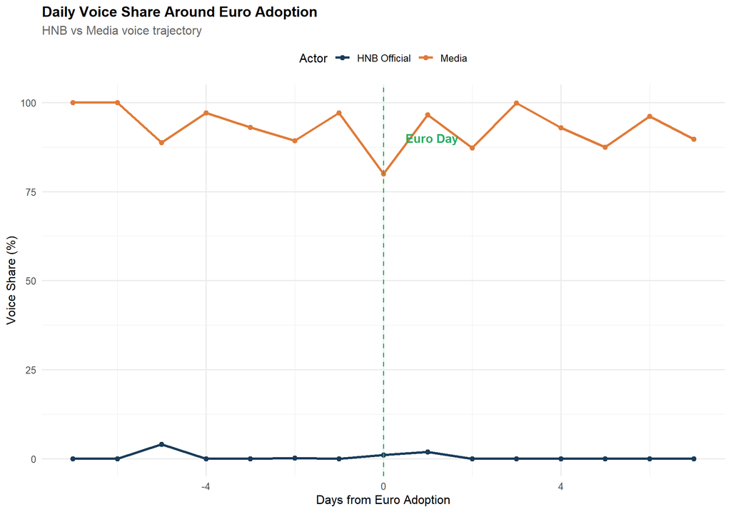

```r
if (nrow(euro_window) > 0) {
  euro_daily <- euro_window[, .(
    HNB_REACH = sum(REACH[ACTOR_TYPE == "HNB Official"], na.rm = TRUE),
    Media_REACH = sum(REACH[ACTOR_TYPE %in% c("Financial Media", "General Media")], na.rm = TRUE),
    Total_REACH = sum(REACH, na.rm = TRUE)
  ), by = date]

  euro_daily[, `:=`(
    HNB_Voice = HNB_REACH / Total_REACH * 100,
    Media_Voice = Media_REACH / Total_REACH * 100,
    Days_From_Euro = as.integer(date - euro_date)
  )]

  euro_long <- euro_daily %>%
    select(date, Days_From_Euro, HNB_Voice, Media_Voice) %>%
    pivot_longer(cols = c(HNB_Voice, Media_Voice), names_to = "Actor", values_to = "Voice_Share") %>%
    mutate(Actor = ifelse(Actor == "HNB_Voice", "HNB Official", "Media"))

  ggplot(euro_long, aes(x = Days_From_Euro, y = Voice_Share, color = Actor)) +
    geom_line(linewidth = 1.2) +
    geom_point(size = 2) +
    geom_vline(xintercept = 0, linetype = "dashed", color = "#27ae60") +
    annotate("text", x = 0.5, y = max(euro_long$Voice_Share, na.rm = TRUE) * 0.9,
             label = "Euro Day", hjust = 0, color = "#27ae60", fontface = "bold") +
    scale_color_manual(values = c("HNB Official" = "#1a3c5a", "Media" = "#e07b39")) +
    labs(
      title = "Daily Voice Share Around Euro Adoption",
      subtitle = "HNB vs Media voice trajectory",
      x = "Days from Euro Adoption",
      y = "Voice Share (%)",
      color = "Actor"
    ) +
    theme(legend.position = "top")
}
```

# 10 Summary and Key Findings

## 10.1 Event Attribution Summary

```r
# Calculate summary metrics
events_above_baseline <- sum(hnb_event_voice$Voice_Delta > 0)
events_below_baseline <- sum(hnb_event_voice$Voice_Delta < 0)
mean_voice_delta <- mean(hnb_event_voice$Voice_Delta)
events_hijacked <- sum(inst_media_voice$Hijacked, na.rm = TRUE)
mean_hijack_index <- mean(inst_media_voice$Hijack_Index, na.rm = TRUE)

tibble(
  Finding = c(
    "Events analyzed",
    "HNB baseline voice share",
    "Events where HNB exceeded baseline",
    "Events where HNB fell below baseline",
    "Mean voice delta during events",
    "Events with media 'hijacking'",
    "Mean hijack index",
    "High-salience period coverage",
    "HNB same-day response rate"
  ),
  Value = c(
    nrow(events),
    sprintf("%.2f%%", baseline_hnb_voice),
    sprintf("%d (%.0f%%)", events_above_baseline, events_above_baseline/nrow(hnb_event_voice)*100),
    sprintf("%d (%.0f%%)", events_below_baseline, events_below_baseline/nrow(hnb_event_voice)*100),
    sprintf("%+.2f pp", mean_voice_delta),
    sprintf("%d events", events_hijacked),
    sprintf("%.1fx", mean_hijack_index),
    sprintf("%.0f%% of days", sum(hnb$High_Salience)/nrow(hnb)*100),
    if(nrow(response_summary) > 0) sprintf("%.0f%%", response_summary[ACTOR_TYPE == "HNB Official", Same_Day_Rate]) else "N/A"
  )
) %>%
  kable(col.names = c("Finding", "Value")) %>%
  kable_styling(bootstrap_options = c("striped", "hover"), full_width = FALSE)
```

| Finding | Value |
| --- | --- |
| Events analyzed | 25 |
| HNB baseline voice share | 1.08% |
| Events where HNB exceeded baseline | 7 (32%) |
| Events where HNB fell below baseline | 15 (68%) |
| Mean voice delta during events | +0.86 pp |
| Events with media 'hijacking' | 10 events |
| Mean hijack index | Infx |
| High-salience period coverage | 22% of days |
| HNB same-day response rate | 56% |

## 10.2 Implications for HNB Communication Strategy

**3. Event Type Vulnerabilities**

Inflation events show the largest HNB voice deficit (-0.77 pp), suggesting targeted communication improvements for this category.

**4. Response Speed**

HNB Official achieves 56% same-day response rate, trailing Financial Media’s 79% rate.

**5. Strategic Recommendations**

- Pre-position communications before predictable events (ECB decisions, scheduled announcements)
- Develop rapid response protocols for breaking events
- Focus resources on event types with largest voice deficits
- Build relationships with high-reach media for coordinated messaging during critical events

# 11 Appendix: Methodological Notes

## 11.1 Voice Share Calculation

$$\text{Voice Share}_i = \frac{\text{REACH}_i}{\sum_{j=1}^{n} \text{REACH}_j} \times 100$$

Where $i$ is the actor type and $j$ indexes all actors in the event window.

## 11.2 Hijack Index

$$\text{Hijack Index} = \frac{\text{Media Voice Share}}{\text{Institutional Voice Share}}$$

- Index = 1: Equal voice
- Index > 1: Media dominates
- Index < 1: Institutional dominates

An event is classified as “hijacked” when:

1. HNB was the expected voice leader, AND
2. Hijack Index > 2 (media has 2x+ attention), OR
3. Institutional Voice Share < 10%

## 11.3 Event Window Definition

Event windows vary by type:

- Euro Transition: ±7 days (extended public interest)
- ECB Policy: ±3 days (rapid market response)
- Inflation: ±5 days (data interpretation period)
- HNB Policy: ±5 days (domestic policy cycle)
- Banking: ±5 days (crisis response period)